# Lab Name

### Exercise 4

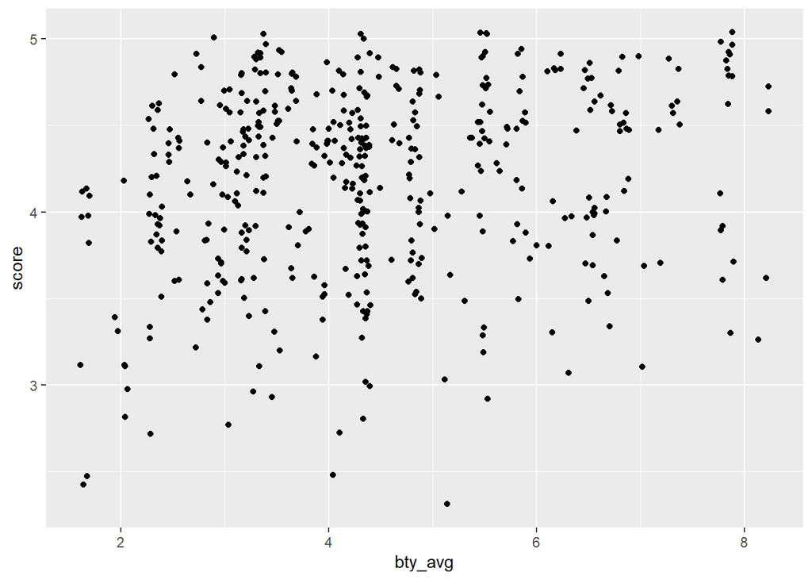

```r
ggplot(data = evals, aes(x = bty_avg, y = score)) +
  geom_jitter()
```

What was misleading about the other scatter plot was the clustering. Before it was spaced out and over plotted over the same point. With geom_jitter we get to add some randomness to get clusters of data that more visually striking that perfectly segmented data that overlaps.

### Exercise 5

```r
m_bty <- lm(score ~ bty_avg, data = evals)
summary(m_bty)
```

```
##
## Call:
## lm(formula = score ~ bty_avg, data = evals)
##
## Residuals:
##     Min      1Q  Median      3Q     Max
## -1.9246 -0.3690  0.1420  0.3977  0.9309
##
## Coefficients:
##             Estimate Std. Error t value Pr(>|t|)
## (Intercept)  3.88034    0.07614   50.96  < 2e-16 ***
## bty_avg      0.06664    0.01629    4.09 5.08e-05 ***
## ---
## Signif. codes:  0 '***' 0.001 '**' 0.01 '*' 0.05 '.' 0.1 ' ' 1
##
## Residual standard error: 0.5348 on 461 degrees of freedom
## Multiple R-squared:  0.03502,    Adjusted R-squared:  0.03293
## F-statistic: 16.73 on 1 and 461 DF,  p-value: 5.083e-05
```

The equation of the linear model looks like this: score=3.880+0.067×bty_avg

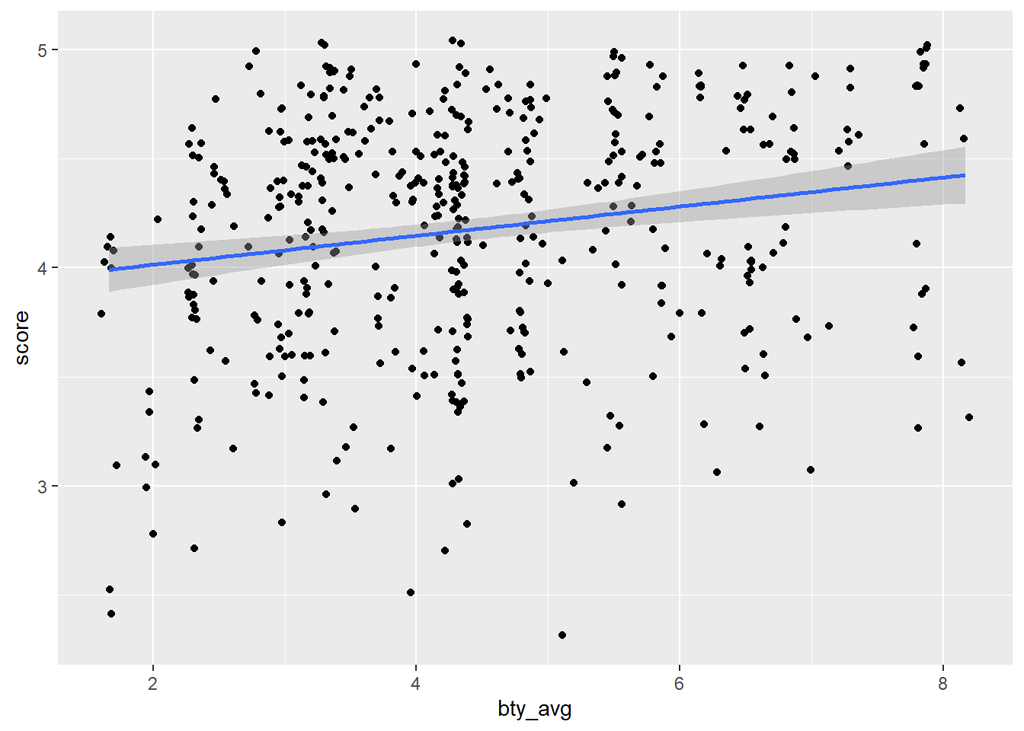

```r
ggplot(data = evals, aes(x = bty_avg, y = score)) +
  geom_jitter() +
  geom_smooth(method = "lm")
```

### Exercise 6

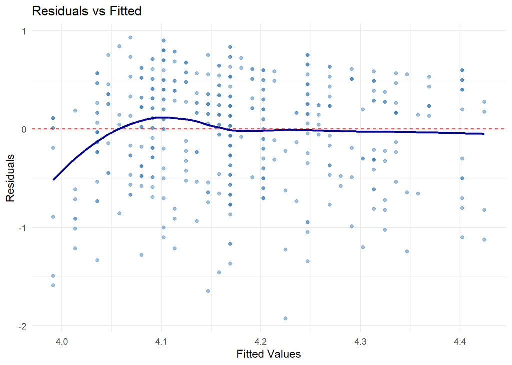

```r
library(ggplot2)

# 1. Residuals vs Fitted (Linearity & Equal Variance)
ggplot(m_bty, aes(x = .fitted, y = .resid)) +
  geom_point(alpha = 0.5, color = "steelblue") +
  geom_hline(yintercept = 0, linetype = "dashed", color = "red") +
  geom_smooth(method = "loess", color = "darkblue", se = FALSE) +
  labs(title = "Residuals vs Fitted",
       x = "Fitted Values", y = "Residuals") +
  theme_minimal()
```

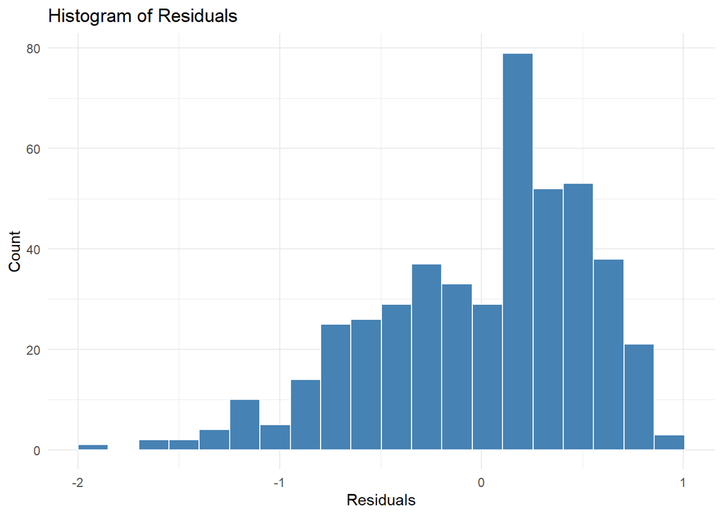

```r
# 2. Histogram of Residuals (Normality)
ggplot(m_bty, aes(x = .resid)) +
  geom_histogram(bins = 20, fill = "steelblue", color = "white") +
  labs(title = "Histogram of Residuals",
       x = "Residuals", y = "Count") +
  theme_minimal()
```

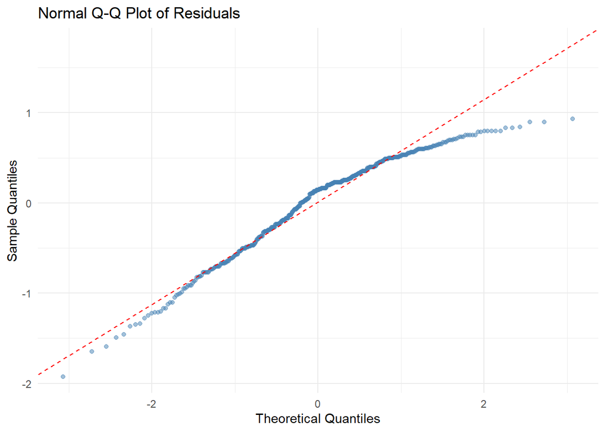

```r
# 3. Normal Q-Q Plot (Normality)
ggplot(m_bty, aes(sample = .resid)) +
  stat_qq(color = "steelblue", alpha = 0.5) +
  stat_qq_line(color = "red", linetype = "dashed") +
  labs(title = "Normal Q-Q Plot of Residuals",
       x = "Theoretical Quantiles", y = "Sample Quantiles") +
  theme_minimal()
```

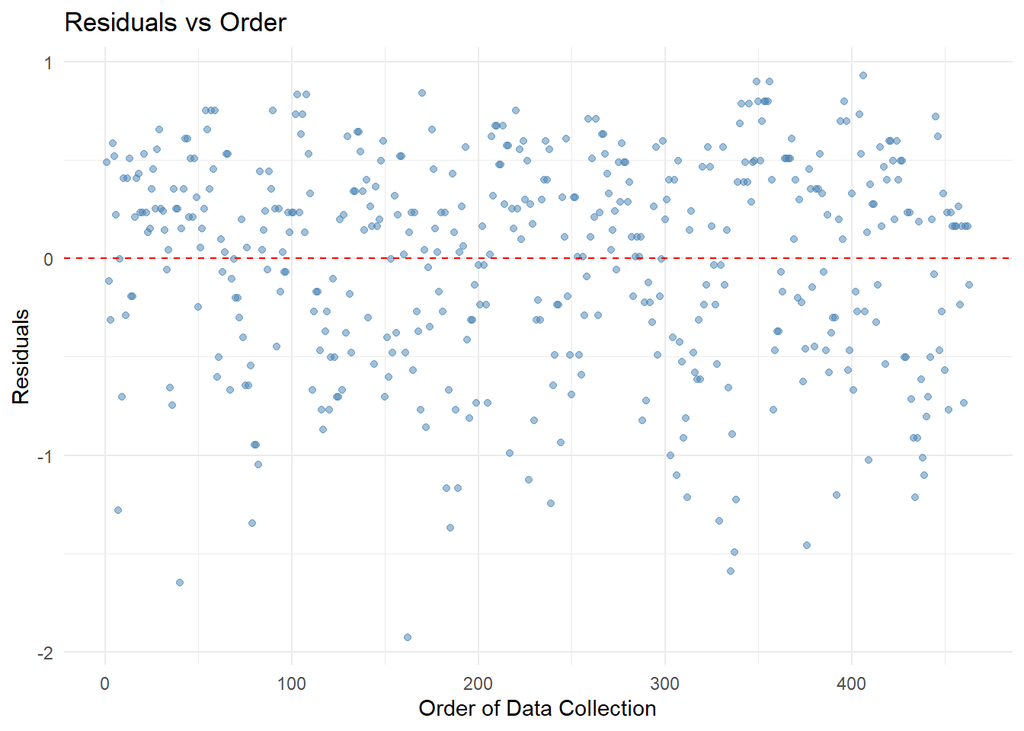

```r
# 4. Residuals vs Order (Independence)
ggplot(m_bty, aes(x = 1:nrow(evals), y = .resid)) +
  geom_point(alpha = 0.5, color = "steelblue") +
  geom_hline(yintercept = 0, linetype = "dashed", color = "red") +
  labs(title = "Residuals vs Order",
       x = "Order of Data Collection", y = "Residuals") +
  theme_minimal()
```

1. Linearity — Residuals vs Fitted The residuals should be randomly scattered around 0 with no patterns.The plot shows roughly random scatter. though with some clustering at higher fitted values which is due the the left skewedness. The condition is kind of satisfied but not perfectly.
2. Nearly Normal Residuals — Histogram & Q-Q Plot This histogram will show a left-skewed distribution show that score is left-skewed as well.
3. Constant Variability — Residuals vs Fitted Looking at the spread of residuals across fitted values, there is some evidence of the variance being not constant meaning that residuals appear more compressed at higher n fitted values due to the ceiling effect at 5.0.
4. Independence — Residuals vs Order The residuals vs order plot shows no time-based pattern or trend.

### Exercise 7

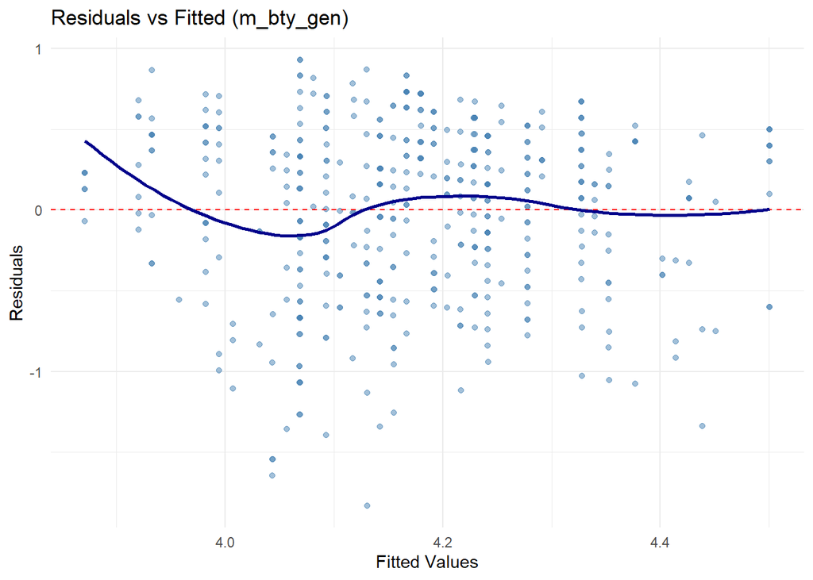

```r
library(ggplot2)

m_bty_gen <- lm(score ~ bty_avg + gender, data = evals)

# 1. Residuals vs Fitted
ggplot(m_bty_gen, aes(x = .fitted, y = .resid)) +
  geom_point(alpha = 0.5, color = "steelblue") +
  geom_hline(yintercept = 0, linetype = "dashed", color = "red") +
  geom_smooth(method = "loess", color = "darkblue", se = FALSE) +
  labs(title = "Residuals vs Fitted (m_bty_gen)",
       x = "Fitted Values", y = "Residuals") +
  theme_minimal()
```

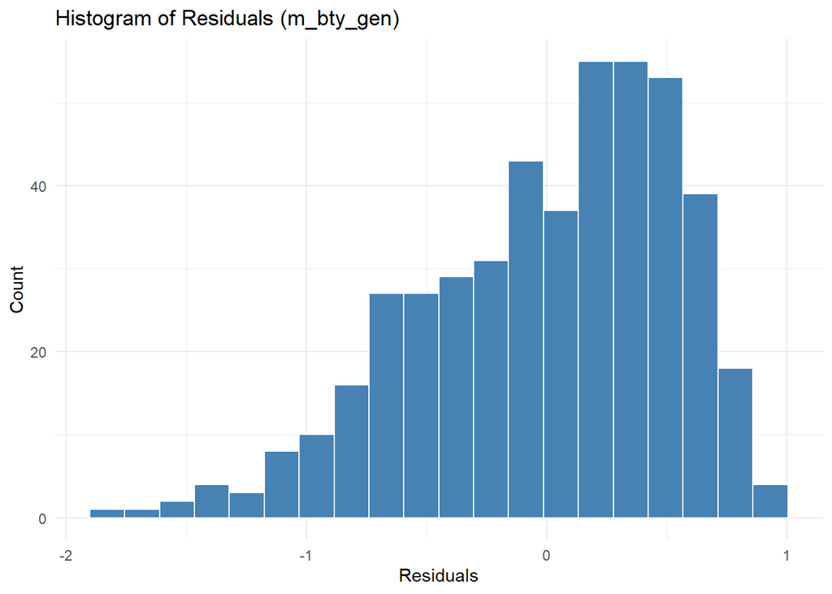

```r
# 2. Histogram of Residuals
ggplot(m_bty_gen, aes(x = .resid)) +
  geom_histogram(bins = 20, fill = "steelblue", color = "white") +
  labs(title = "Histogram of Residuals (m_bty_gen)",
       x = "Residuals", y = "Count") +
  theme_minimal()
```

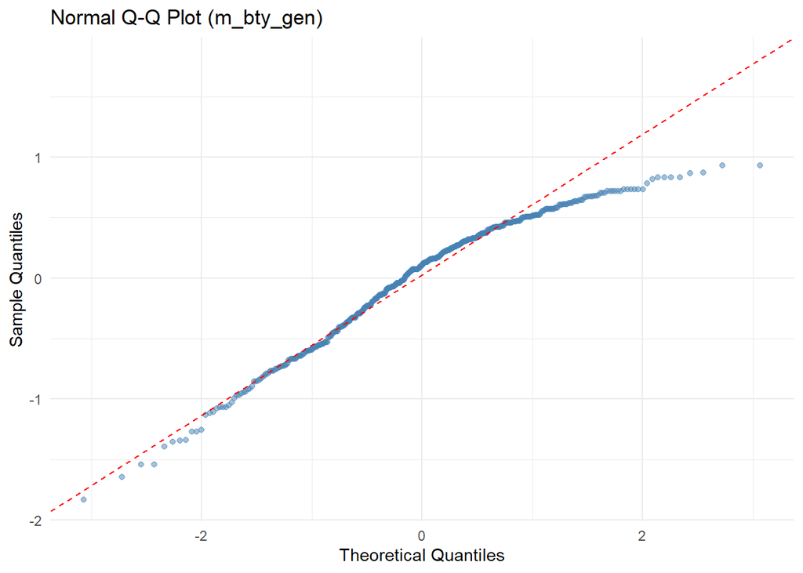

```r
# 3. Q-Q Plot
ggplot(m_bty_gen, aes(sample = .resid)) +
  stat_qq(color = "steelblue", alpha = 0.5) +
  stat_qq_line(color = "red", linetype = "dashed") +
  labs(title = "Normal Q-Q Plot (m_bty_gen)",
       x = "Theoretical Quantiles", y = "Sample Quantiles") +
  theme_minimal()
```

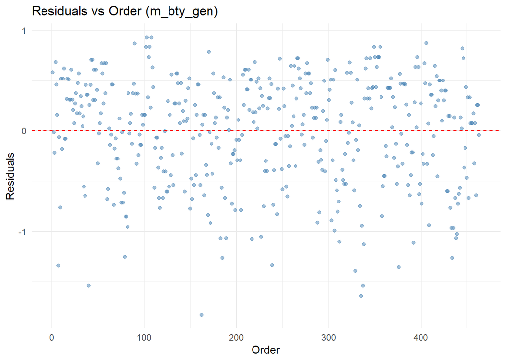

```r
# 4. Residuals vs Order
ggplot(m_bty_gen, aes(x = 1:nrow(evals), y = .resid)) +
  geom_point(alpha = 0.5, color = "steelblue") +
  geom_hline(yintercept = 0, linetype = "dashed", color = "red") +
  labs(title = "Residuals vs Order (m_bty_gen)",
       x = "Order", y = "Residuals") +
  theme_minimal()
```

The conditions for for this model are reasonable and the p-values can be trusted.

### Exercise 8

bty_avg is still a significant predictor of score. Adding gender to the model changed the parameter estimate for bty_avg by the increased of bty_avg from about 0.067 to 0.074.

```r
summary(m_bty)
```

```
##
## Call:
## lm(formula = score ~ bty_avg, data = evals)
##
## Residuals:
##     Min      1Q  Median      3Q     Max
## -1.9246 -0.3690  0.1420  0.3977  0.9309
##
## Coefficients:
##             Estimate Std. Error t value Pr(>|t|)
## (Intercept)  3.88034    0.07614   50.96  < 2e-16 ***
## bty_avg      0.06664    0.01629    4.09 5.08e-05 ***
## ---
## Signif. codes:  0 '***' 0.001 '**' 0.01 '*' 0.05 '.' 0.1 ' ' 1
##
## Residual standard error: 0.5348 on 461 degrees of freedom
## Multiple R-squared:  0.03502,    Adjusted R-squared:  0.03293
## F-statistic: 16.73 on 1 and 461 DF,  p-value: 5.083e-05
```

```r
summary(m_bty_gen)
```

```
##
## Call:
## lm(formula = score ~ bty_avg + gender, data = evals)
##
## Residuals:
##     Min      1Q  Median      3Q     Max
## -1.8305 -0.3625  0.1055  0.4213  0.9314
##
## Coefficients:
##             Estimate Std. Error t value Pr(>|t|)
## (Intercept)  3.74734    0.08466  44.266  < 2e-16 ***
## bty_avg      0.07416    0.01625   4.563 6.48e-06 ***
## gendermale   0.17239    0.05022   3.433 0.000652 ***
## ---
## Signif. codes:  0 '***' 0.001 '**' 0.01 '*' 0.05 '.' 0.1 ' ' 1
##
## Residual standard error: 0.5287 on 460 degrees of freedom
## Multiple R-squared:  0.05912,    Adjusted R-squared:  0.05503
## F-statistic: 14.45 on 2 and 460 DF,  p-value: 8.177e-07
```

### Exercise 10

```r
m_bty_rank <- lm(score ~ bty_avg + rank, data = evals)
summary(m_bty_rank)
```

```
##
## Call:
## lm(formula = score ~ bty_avg + rank, data = evals)
##
## Residuals:
##     Min      1Q  Median      3Q     Max
## -1.8713 -0.3642  0.1489  0.4103  0.9525
##
## Coefficients:
##                  Estimate Std. Error t value Pr(>|t|)
## (Intercept)       3.98155    0.09078  43.860  < 2e-16 ***
## bty_avg           0.06783    0.01655   4.098 4.92e-05 ***
## ranktenure track -0.16070    0.07395  -2.173   0.0303 *
## ranktenured      -0.12623    0.06266  -2.014   0.0445 *
## ---
## Signif. codes:  0 '***' 0.001 '**' 0.01 '*' 0.05 '.' 0.1 ' ' 1
##
## Residual standard error: 0.5328 on 459 degrees of freedom
## Multiple R-squared:  0.04652,    Adjusted R-squared:  0.04029
## F-statistic: 7.465 on 3 and 459 DF,  p-value: 6.88e-05
```

R will add another line into the regression summary we know this because of the recording of the ranked variable twice.

### Exercise 11

I assume that cls_profs to have the highest p-value because I do not see a reason why the number of professors teaching other sections of the same course woulds affect the professors ratings compared to other factors like gender or bty_avg. I think that cls_level could also be close or higher than cls_profs because cls_level might be not matter unless the students pin the harder course work on the professors teaching ability.

### Exercise 12

```r
m_full <- lm(score ~ rank + gender + ethnicity + language + age +
               cls_perc_eval + cls_students + cls_level + cls_profs +
               cls_credits + bty_avg + pic_outfit + pic_color,
             data = evals)
summary(m_full)
```

```
##
## Call:
## lm(formula = score ~ rank + gender + ethnicity + language + age +
##     cls_perc_eval + cls_students + cls_level + cls_profs + cls_credits +
##     bty_avg + pic_outfit + pic_color, data = evals)
##
## Residuals:
##      Min       1Q   Median       3Q      Max
## -1.77397 -0.32432  0.09067  0.35183  0.95036
##
## Coefficients:
##                         Estimate Std. Error t value Pr(>|t|)
## (Intercept)            4.0952141  0.2905277  14.096  < 2e-16 ***
## ranktenure track      -0.1475932  0.0820671  -1.798  0.07278 .
## ranktenured           -0.0973378  0.0663296  -1.467  0.14295
## gendermale             0.2109481  0.0518230   4.071 5.54e-05 ***
## ethnicitynot minority  0.1234929  0.0786273   1.571  0.11698
## languagenon-english   -0.2298112  0.1113754  -2.063  0.03965 *
## age                   -0.0090072  0.0031359  -2.872  0.00427 **
## cls_perc_eval          0.0053272  0.0015393   3.461  0.00059 ***
## cls_students           0.0004546  0.0003774   1.205  0.22896
## cls_levelupper         0.0605140  0.0575617   1.051  0.29369
## cls_profssingle       -0.0146619  0.0519885  -0.282  0.77806
## cls_creditsone credit  0.5020432  0.1159388   4.330 1.84e-05 ***
## bty_avg                0.0400333  0.0175064   2.287  0.02267 *
## pic_outfitnot formal  -0.1126817  0.0738800  -1.525  0.12792
## pic_colorcolor        -0.2172630  0.0715021  -3.039  0.00252 **
## ---
## Signif. codes:  0 '***' 0.001 '**' 0.01 '*' 0.05 '.' 0.1 ' ' 1
##
## Residual standard error: 0.498 on 448 degrees of freedom
## Multiple R-squared:  0.1871, Adjusted R-squared:  0.1617
## F-statistic: 7.366 on 14 and 448 DF,  p-value: 6.552e-14
```

The models shows that both cls_profs and cls_level have the top two higest p value but cls_profs has significantly more.

### Exercise 13

the ethnicity not minority variable increases the score by about 0.1235 or 12% when all other variables are constant.

### Exercise 14

```r
m_full2 <- lm(score ~ rank + gender + ethnicity + language + age +
                cls_perc_eval + cls_students + cls_level +
                cls_credits + bty_avg + pic_outfit + pic_color,
              data = evals)
summary(m_full2)
```

```
##
## Call:
## lm(formula = score ~ rank + gender + ethnicity + language + age +
##     cls_perc_eval + cls_students + cls_level + cls_credits +
##     bty_avg + pic_outfit + pic_color, data = evals)
##
## Residuals:
##     Min      1Q  Median      3Q     Max
## -1.7836 -0.3257  0.0859  0.3513  0.9551
##
## Coefficients:
##                         Estimate Std. Error t value Pr(>|t|)
## (Intercept)            4.0872523  0.2888562  14.150  < 2e-16 ***
## ranktenure track      -0.1476746  0.0819824  -1.801 0.072327 .
## ranktenured           -0.0973829  0.0662614  -1.470 0.142349
## gendermale             0.2101231  0.0516873   4.065 5.66e-05 ***
## ethnicitynot minority  0.1274458  0.0772887   1.649 0.099856 .
## languagenon-english   -0.2282894  0.1111305  -2.054 0.040530 *
## age                   -0.0089992  0.0031326  -2.873 0.004262 **
## cls_perc_eval          0.0052888  0.0015317   3.453 0.000607 ***
## cls_students           0.0004687  0.0003737   1.254 0.210384
## cls_levelupper         0.0606374  0.0575010   1.055 0.292200
## cls_creditsone credit  0.5061196  0.1149163   4.404 1.33e-05 ***
## bty_avg                0.0398629  0.0174780   2.281 0.023032 *
## pic_outfitnot formal  -0.1083227  0.0721711  -1.501 0.134080
## pic_colorcolor        -0.2190527  0.0711469  -3.079 0.002205 **
## ---
## Signif. codes:  0 '***' 0.001 '**' 0.01 '*' 0.05 '.' 0.1 ' ' 1
##
## Residual standard error: 0.4974 on 449 degrees of freedom
## Multiple R-squared:  0.187,  Adjusted R-squared:  0.1634
## F-statistic: 7.943 on 13 and 449 DF,  p-value: 2.336e-14
```

After dropping cls_profs, the coefficients and significance levels of the remaining variables will change very little. This tells us that cls_profs was not collinear with the other predictors if it were, removing it would cause noticeable shifts in other estimates. Its removal has minimal impact, further confirming it was a non-informative variable that can be safely excluded.

### Exercise 15

```r
back_select <- lm(score ~ gender + ethnicity + language + age +
                cls_perc_eval + cls_credits + bty_avg +
                pic_outfit + pic_color,
              data = evals)
summary(back_select)
```

```
##
## Call:
## lm(formula = score ~ gender + ethnicity + language + age + cls_perc_eval +
##     cls_credits + bty_avg + pic_outfit + pic_color, data = evals)
##
## Residuals:
##     Min      1Q  Median      3Q     Max
## -1.8455 -0.3221  0.1013  0.3745  0.9051
##
## Coefficients:
##                        Estimate Std. Error t value Pr(>|t|)
## (Intercept)            3.907030   0.244889  15.954  < 2e-16 ***
## gendermale             0.202597   0.050102   4.044 6.18e-05 ***
## ethnicitynot minority  0.163818   0.075158   2.180 0.029798 *
## languagenon-english   -0.246683   0.106146  -2.324 0.020567 *
## age                   -0.006925   0.002658  -2.606 0.009475 **
## cls_perc_eval          0.004942   0.001442   3.427 0.000666 ***
## cls_creditsone credit  0.517205   0.104141   4.966 9.68e-07 ***
## bty_avg                0.046732   0.017091   2.734 0.006497 **
## pic_outfitnot formal  -0.113939   0.067168  -1.696 0.090510 .
## pic_colorcolor        -0.180870   0.067456  -2.681 0.007601 **
## ---
## Signif. codes:  0 '***' 0.001 '**' 0.01 '*' 0.05 '.' 0.1 ' ' 1
##
## Residual standard error: 0.4982 on 453 degrees of freedom
## Multiple R-squared:  0.1774, Adjusted R-squared:  0.161
## F-statistic: 10.85 on 9 and 453 DF,  p-value: 2.441e-15
```

### Excercise 16

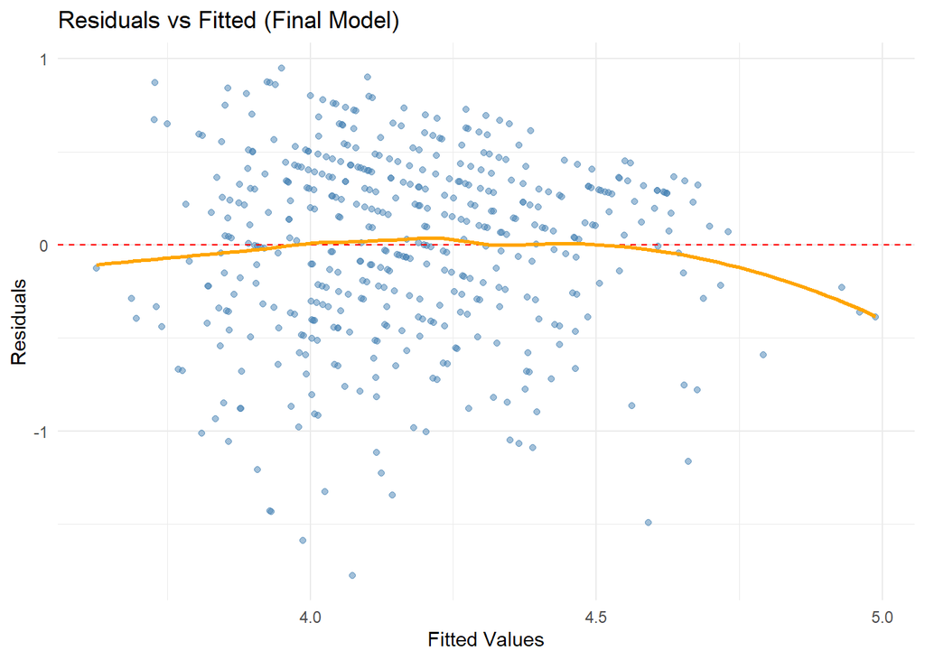

```r
# Residuals vs Fitted
ggplot(m_full, aes(x = .fitted, y = .resid)) +
  geom_point(alpha = 0.5, color = "steelblue") +
  geom_hline(yintercept = 0, linetype = "dashed", color = "red") +
  geom_smooth(method = "loess", color = "orange", se = FALSE) +
  labs(title = "Residuals vs Fitted (Final Model)",
       x = "Fitted Values", y = "Residuals") +
  theme_minimal()
```

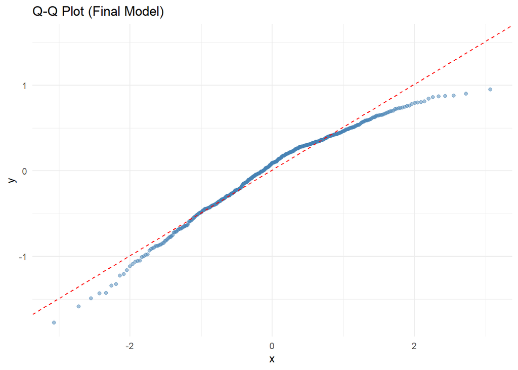

```r
# Q-Q Plot
ggplot(m_full, aes(sample = .resid)) +
  stat_qq(color = "steelblue", alpha = 0.5) +
  stat_qq_line(color = "red", linetype = "dashed") +
  labs(title = "Q-Q Plot (Final Model)") +
  theme_minimal()
```

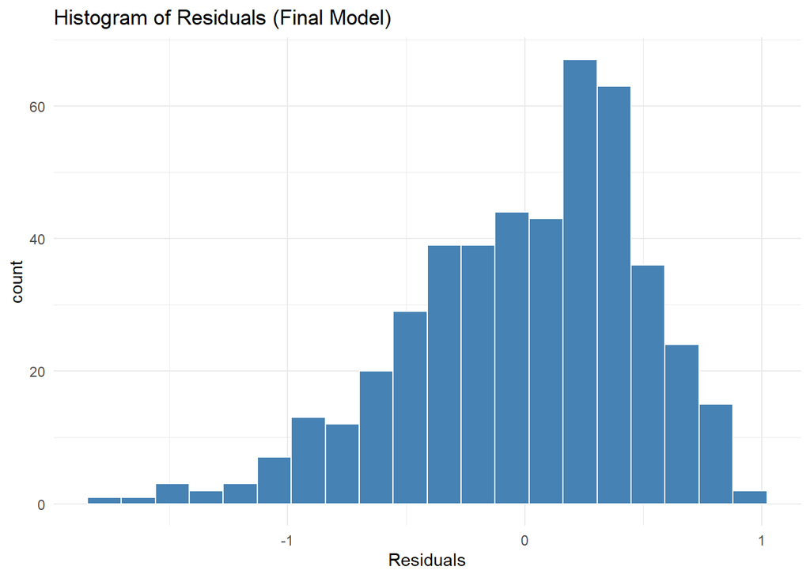

```r
# Histogram of residuals
ggplot(m_full, aes(x = .resid)) +
  geom_histogram(bins = 20, fill = "steelblue", color = "white") +
  labs(title = "Histogram of Residuals (Final Model)",
       x = "Residuals") +
  theme_minimal()
```

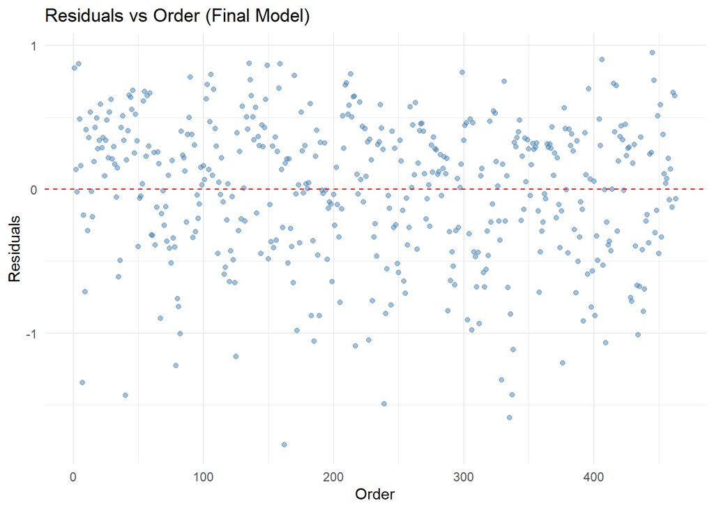

```r
# Residuals vs Order
ggplot(m_full, aes(x = 1:nrow(evals), y = .resid)) +
  geom_point(alpha = 0.5, color = "steelblue") +
  geom_hline(yintercept = 0, linetype = "dashed", color = "red") +
  labs(title = "Residuals vs Order (Final Model)",
       x = "Order", y = "Residuals") +
  theme_minimal()
```

### Exercise 17

Yes, this sampling design does have implications for the independence condition. Since each row represents a course rather than a professor, and professors teach multiple courses, multiple observations come from the same professor. Rows sharing a professor are not truly independent of one another, as a professor’s characteristics (teaching style, personality, appearance) will influence all of their course evaluations similarly. This violates the independence condition and means standard errors may be underestimated.

### Exercise 18

Based on the final model, a professor at UT Austin associated with a high evaluation score would tend to have the following characteristics:

male, non minority, English speaking, younger in age, teaches a one-credit course, profile with a black and white photo, student rated the professor with a high average beauty score and received a high number of evaluations from students.

### Exercise 19

No, I would not be comfortable to generalize my conclusions to apply to professors generally at any university. There are so many university in America and we need a sample size large enough to represent that to even get close to any generalizations. Not to mention different communities value different attributes so it may not even prove worthwhile to do a sample that large.